# Confirmatory Factor Analysis with a Small Sample

Juan C. Correa

2024-01-06

# Context

CFA is a well-known technique in psychology and social sciences. Despite its reputation, like any other technique, it also has its limitations. For example, in educational research, it is quite common to have small sample size (few observations) if they are collected through survey-based techniques such as scales or questionnaires. Our following case builds upon the context of a COIL experience where 65 students (i.e., 33 from Colombia and 32 from Ecuador) got together during six weeks for a two-hour-sessions per week using Google Classroom. Let’s open the data an conduct a standard Confirmatory Factor Analysis.

The data relates to 15 items (observed variables) which are theoretically linked to the concept of Transactive Memory System (TMS). TMS refers to the way people work in collaboration with others. Thus, TMS can be regarded as a “Collaboration Skill”. Here, we want to test the psychometric structure of the scale originally developed for English-speakers by Lewis (2003) and re-adapted for Spanish by García-Chitiva (2021).

## Testing Univariate and Multivariate Normal Distribution Assumptions

The evaluation of these assumptions is relatively straightforward through exploratory data visualization of kernel density plots and the Henze-Zirkler test implemented in the R package MVN

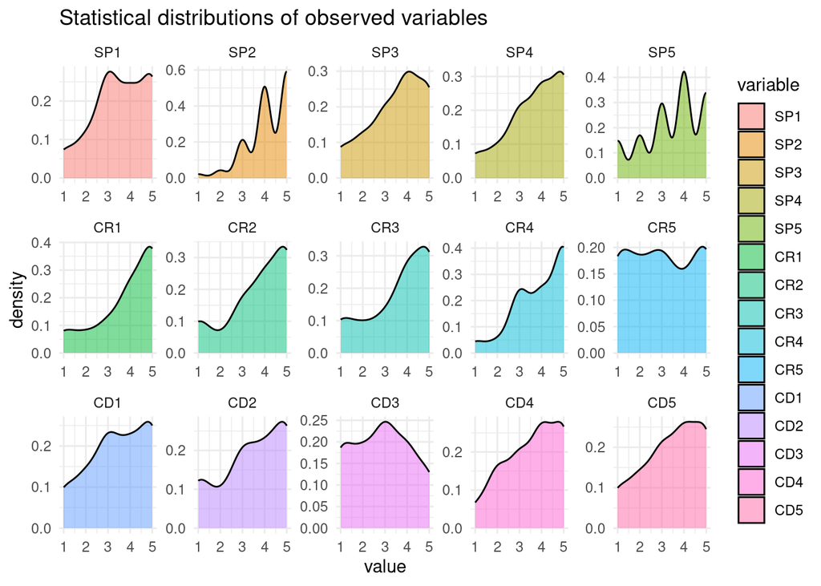

```
## $multivariateNormality
##            Test       HZ p value MVN
## 1 Henze-Zirkler 1.146849       0  NO
##
## $univariateNormality
##                Test  Variable Statistic   p value Normality
## 1  Anderson-Darling    SP1       2.6425  <0.001      NO
## 2  Anderson-Darling    SP2       4.8075  <0.001      NO
## 3  Anderson-Darling    SP3       2.8051  <0.001      NO
## 4  Anderson-Darling    SP4       3.1993  <0.001      NO
## 5  Anderson-Darling    SP5       2.6057  <0.001      NO
## 6  Anderson-Darling    CR1       5.1230  <0.001      NO
## 7  Anderson-Darling    CR2       4.1894  <0.001      NO
## 8  Anderson-Darling    CR3       4.2579  <0.001      NO
## 9  Anderson-Darling    CR4       4.3315  <0.001      NO
## 10 Anderson-Darling    CR5       2.8246  <0.001      NO
## 11 Anderson-Darling    CD1       2.5583  <0.001      NO
## 12 Anderson-Darling    CD2       3.1696  <0.001      NO
## 13 Anderson-Darling    CD3       2.0870  <0.001      NO
## 14 Anderson-Darling    CD4       2.7675  <0.001      NO
## 15 Anderson-Darling    CD5       2.5773  <0.001      NO
##
## $Descriptives
##      n     Mean   Std.Dev Median Min Max 25th 75th        Skew    Kurtosis
## SP1 65 3.553846 1.2378253      4   1   5    3    5 -0.43783261 -0.77860744
## SP2 65 4.169231 0.9112017      4   1   5    4    5 -1.06337598  0.95482009
## SP3 65 3.553846 1.2751320      4   1   5    3    5 -0.56353505 -0.77350691
## SP4 65 3.707692 1.2465337      4   1   5    3    5 -0.68443217 -0.54814357
## SP5 65 3.461538 1.2878874      4   1   5    3    4 -0.49962264 -0.84453847
## CR1 65 3.892308 1.3124771      4   1   5    3    5 -0.98873413 -0.23798724
## CR2 65 3.738462 1.3495013      4   1   5    3    5 -0.84124919 -0.47530792
## CR3 65 3.692308 1.3797993      4   1   5    3    5 -0.78262376 -0.70063989
## CR4 65 3.953846 1.1378539      4   1   5    3    5 -0.85132191 -0.07327122
## CR5 65 3.015385 1.5154651      3   1   5    2    5  0.02747577 -1.45291738
## CD1 65 3.446154 1.3349950      4   1   5    3    5 -0.37141430 -1.04945333
## CD2 65 3.476923 1.4154029      4   1   5    3    5 -0.50727979 -1.02579479
## CD3 65 2.861538 1.3448620      3   1   5    2    4  0.05853636 -1.19034460
## CD4 65 3.569231 1.2496153      4   1   5    3    5 -0.43877950 -0.96462795
## CD5 65 3.461538 1.3237839      4   1   5    3    5 -0.43558370 -0.99126936
```

## Confirmatory Factor Analysis

Our first measurement model specification can be regarded as a confirmatory factor analysis, as it sets the full theoretical factor structure with the following three latent variables: Specialization (SP), Credibility (CR), and Coordination (CD) with 15 observed variables.

### A First Model

Before showing the goodness-of-fit for this model, we highlight its standardized statistical estimates, so we can spot which items should be removed due to their low association with the latent variables.

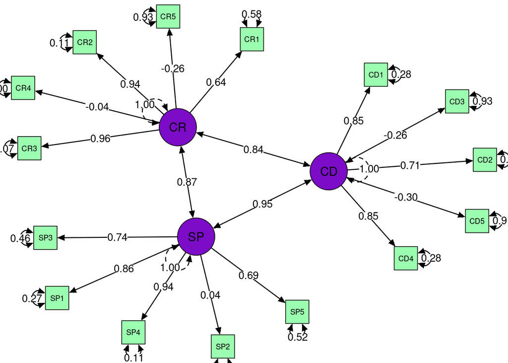

It should be evident that the following items didn’t behave as expected due to their almost-zero or lower-than-zero factor loadings which contradict theoretical expectations:

- CR4 (factor loading = -0.04)
- CR5 (factor loading = -0.26)
- SP2 (factor loading = 0.04)
- CD3 (factor loading = -0.26)
- CD5 (factor loading = -0.30)

Before removing these items from our original specification, we want to highlight the model’s fit through the maximum likelihood (ML) estimation method with (Model B) and without (Model A) the Satorra-Bentler correction for the $\chi^2$ test that yields to robust goodness of fit, as follows:

|  | Fit.Index | ModelA | ModelB |
| --- | --- | --- | --- |
| chisq | Chi2 | 177.636 | 153.851 |
| cfi | CFI | 0.856 | 0.873 |
| tli | TLI | 0.827 | 0.847 |
| rmsea | RMSEA | 0.127 | 0.117 |
| srmr | SRMR | 0.109 | 0.109 |
| aic | AIC | 2289.285 | 2289.285 |
| bic | BIC | 2393.655 | 2393.655 |

## Searching the cause of misfit

The above model shows a poor fit despite its estimates with high magnitudes and statistical significance. The co-existence of these two aspects of the model raises concerns about the structure of the model itself. 1. Are the parameter estimates biased because of non-normality, misspecification, or small sample? 2. Are the poor goodness-of-fit the results of non-normality, misspecification or small sample?

### A Second Model

Our data-driven approach at this moment, can help newcomers to anticipate that our original model should outperform if we removed the items that didn’t behave as expected. Let’s see if this is the case.

The results of this second model look as follows:

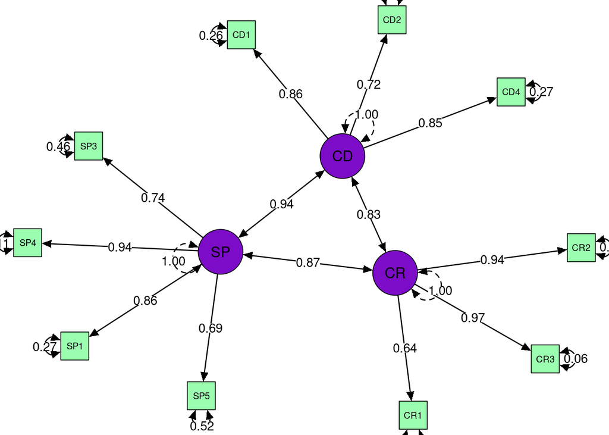

Now, let’s check the results of this second model

```
##      chisq         df     pvalue
## 38.4920904 32.0000000  0.1992038
```

```
##  chisq.scaled     df.scaled pvalue.scaled
##    26.7374915    32.0000000     0.7301062
```

```
##        cfi        tli cfi.scaled tli.scaled cfi.robust tli.robust
##  0.9879471  0.9830506  1.0000000  1.0167344  1.0000000  1.0201119
```

```
##          rmsea rmsea.ci.lower rmsea.ci.upper rmsea.ci.level   rmsea.pvalue
##     0.05586768     0.00000000     0.11243156     0.90000000     0.41297390
```

```
##          rmsea.scaled rmsea.ci.lower.scaled rmsea.ci.upper.scaled
##            0.00000000            0.00000000            0.05752564
##   rmsea.pvalue.scaled
##            0.92574605
```

```
##          rmsea.robust rmsea.ci.lower.robust rmsea.ci.upper.robust
##            0.00000000            0.00000000            0.08348741
##   rmsea.pvalue.robust
##            0.84484116
```

```
##      srmr
## 0.0382286
```

At this moment, a practitioner might be tempted to claim that this model proved to be satisfactory from a statistical viewpoint, given its following results:

- All standardized estimates for factor loadings are high and statistically significant
- The covariance between latent variables are high and statistically significant
- The goodness-of-fit indices fulfil the rules of thumb suggested by Hu and Bentler (1999)

Even though all of these results are promising, we will show that they should not be taken for granted, due to the existence of improper solutions in the estimation process. To conduct a final check (often not recognized by practitioners) a good strategy might be to look at the estimated variance-covariance matrix for all observed and latent variables. This estimated matrix is $\hat{\theta}_\delta$ from the general equation introduced by Bollen (1989) $\Sigma = \Sigma(\hat{\theta}_\delta)$.

## The bad news about ML

The bad news about the “first” and “second” confirmatory factor analyses is that the goodness-of-fit reported for both of these models are misleading even if they look okay because they are the result of an improper solution that is visible when we inspect the estimated variance-covariance matrix for all observed and latent variables.

```r
m1 <- lavInspect(result2, what = "vcov.std.all")
EIGEN <- eigen(m1)
EIGEN$values
```

```
##  [1]  1.207609e-01  5.925567e-02  4.811115e-02  4.352126e-02  3.093759e-02
##  [6]  3.010522e-02  2.474961e-02  2.128846e-02  1.921119e-02  1.753589e-02
## [11]  1.390055e-02  1.357636e-02  1.035674e-02  8.838192e-03  8.737255e-03
## [16]  7.036404e-03  5.349322e-03  4.934950e-03  3.716738e-03  3.464142e-03
## [21]  3.001569e-03  2.542594e-03  2.134308e-03  1.741152e-03  1.664020e-03
## [26]  1.268516e-03  9.770393e-04  7.667798e-04  5.469053e-04  4.268446e-04
## [31]  3.213384e-04  2.611717e-04  1.017014e-04  3.411283e-18  1.009274e-18
## [36]  9.991793e-19  1.486767e-19 -8.527676e-20 -6.451786e-19 -8.671951e-19
## [41] -1.102122e-18 -1.379846e-18 -1.905775e-18 -2.394056e-18 -2.452155e-18
## [46] -4.034541e-18 -4.765757e-18 -8.322736e-18
```

```r
m2 <- lavInspect(result4, what = "vcov.std.all")
EIGEN2 <- eigen(m2)
EIGEN2$values
```

```
##  [1]  1.060216e-01  3.967105e-02  2.862141e-02  2.716589e-02  2.459553e-02
##  [6]  2.017251e-02  1.181716e-02  1.076575e-02  9.255230e-03  7.801025e-03
## [11]  6.261551e-03  3.462509e-03  3.103688e-03  2.860379e-03  2.536757e-03
## [16]  1.695321e-03  1.595773e-03  1.382230e-03  7.988911e-04  6.352218e-04
## [21]  5.531091e-04  3.887305e-04  1.507677e-04  1.554513e-17  4.450306e-18
## [26]  4.349668e-18  3.931632e-19 -2.596309e-19 -1.987357e-18 -2.297930e-18
## [31] -5.193291e-18 -5.865017e-18 -1.561251e-17
```

The definitive proof that this solution is not admissible is evident if you run the Cholesky decomposition by running `chol(m1)` for the “first” model and `chol(m2)` for the “second” model.

# Beyond Maximum Likelihood

Because the strategy of maximum likelihood estimation method was the common element between these two models, then we need to use another estimation method. An alternative is known as “Model-implied instrumental variables.” In this approach, the model is translated to a set of (regression) equations. Next, each latent variable in these equations is replaced with its marker indicator (usually the ﬁrst indicator, where the factor loading is ﬁxed to unity and the intercept is ﬁxed to zero) minus its residual error term. The resulting equations no longer contain any latent variables but have a more complex error structure.

Importantly, ordinary least squares estimation is no longer suitable for solving these equations because some predictors are now correlated with the error term in the equation. This is where the instrumental variables (also called instruments) come into play. For each equation, a set of instrumental variables must be found. An instrumental variable must be uncorrelated with the error term of the equation but strongly correlated with the problematic predictor. Usually, instrumental variables are sought outside the model, but in Bollen’s approach, the instrumental variables are selected from the observed variables that are part of the model. Several (automated) procedures to ﬁnd these instrumental variables within the model have been developed. Once the instruments are selected, an estimation procedure is needed to estimate all the coeﬃcients of the equations. Econometricians developed a popular method to accomplish this called two-stage least squares (2SLS).

```
## Model Equation Information
##
##  LHS   RHS   MIIVs
##  SP2   SP1   SP3, SP4, SP5, CR1, CR2, CR3, CR4, CR5, CD1, CD2, CD3, CD4, CD5
##  SP3   SP1   SP2, SP4, SP5, CR1, CR2, CR3, CR4, CR5, CD1, CD2, CD3, CD4, CD5
##  SP4   SP1   SP2, SP3, SP5, CR1, CR2, CR3, CR4, CR5, CD1, CD2, CD3, CD4, CD5
##  SP5   SP1   SP2, SP3, SP4, CR1, CR2, CR3, CR4, CR5, CD1, CD2, CD3, CD4, CD5
##  CR2   CR1   SP1, SP2, SP3, SP4, SP5, CR3, CR4, CR5, CD1, CD2, CD3, CD4, CD5
##  CR3   CR1   SP1, SP2, SP3, SP4, SP5, CR2, CR4, CR5, CD1, CD2, CD3, CD4, CD5
##  CR4   CR1   SP1, SP2, SP3, SP4, SP5, CR2, CR3, CR5, CD1, CD2, CD3, CD4, CD5
##  CR5   CR1   SP1, SP2, SP3, SP4, SP5, CR2, CR3, CR4, CD1, CD2, CD3, CD4, CD5
##  CD2   CD1   SP1, SP2, SP3, SP4, SP5, CR1, CR2, CR3, CR4, CR5, CD3, CD4, CD5
##  CD3   CD1   SP1, SP2, SP3, SP4, SP5, CR1, CR2, CR3, CR4, CR5, CD2, CD4, CD5
##  CD4   CD1   SP1, SP2, SP3, SP4, SP5, CR1, CR2, CR3, CR4, CR5, CD2, CD3, CD5
##  CD5   CD1   SP1, SP2, SP3, SP4, SP5, CR1, CR2, CR3, CR4, CR5, CD2, CD3, CD4
```

```
## Model Equation Information
##
##  LHS   RHS   MIIVs
##  SP2   SP1   SP3, SP4, SP5, CR1, CR2, CR3, CR4, CR5, CD1, CD2, CD3, CD4, CD5
##  SP3   SP1   SP2, SP4, SP5, CR1, CR2, CR3, CR4, CR5, CD1, CD2, CD3, CD4, CD5
##  SP4   SP1   SP2, SP3, SP5, CR1, CR2, CR3, CR4, CR5, CD1, CD2, CD3, CD4, CD5
##  SP5   SP1   SP2, SP3, SP4, CR1, CR2, CR3, CR4, CR5, CD1, CD2, CD3, CD4, CD5
##  CR2   CR1   SP1, SP2, SP3, SP4, SP5, CR3, CR4, CR5, CD1, CD2, CD3, CD4, CD5
##  CR3   CR1   SP1, SP2, SP3, SP4, SP5, CR2, CR4, CR5, CD1, CD2, CD3, CD4, CD5
##  CR4   CR1   SP1, SP2, SP3, SP4, SP5, CR2, CR3, CR5, CD1, CD2, CD3, CD4, CD5
##  CR5   CR1   SP1, SP2, SP3, SP4, SP5, CR2, CR3, CR4, CD1, CD2, CD3, CD4, CD5
##  CD2   CD1   SP1, SP2, SP3, SP4, SP5, CR1, CR2, CR3, CR4, CR5, CD3, CD4, CD5
##  CD3   CD1   SP1, SP2, SP3, SP4, SP5, CR1, CR2, CR3, CR4, CR5, CD2, CD4, CD5
##  CD4   CD1   SP1, SP2, SP3, SP4, SP5, CR1, CR2, CR3, CR4, CR5, CD2, CD3, CD5
##  CD5   CD1   SP1, SP2, SP3, SP4, SP5, CR1, CR2, CR3, CR4, CR5, CD2, CD3, CD4
##
##
##
##
## MIIV SEARCH INFORMATION:
##
##    Equation Number:                                  1
##    Equation Type:                          Measurement
##    Outcome Variable:                               SP2
##    Explanatory Variable(s):
##      SP(SP1)
##    Composite Disturbance:
##      e.SP2, e.SP1
##    Instrumental Variable(s):
##      SP3, SP4, SP5, CR1, CR2, CR3, CR4, CR5, CD1,
##      CD2, CD3, CD4, CD5
##
##
##    Equation Number:                                  2
##    Equation Type:                          Measurement
##    Outcome Variable:                               SP3
##    Explanatory Variable(s):
##      SP(SP1)
##    Composite Disturbance:
##      e.SP3, e.SP1
```

[output cut: 108 more lines]

```
##    Instrumental Variable(s):
##      SP1, SP2, SP3, SP4, SP5, CR1, CR2, CR3, CR4,
##      CR5, CD2, CD3, CD5
##
##
##    Equation Number:                                 12
##    Equation Type:                          Measurement
##    Outcome Variable:                               CD5
##    Explanatory Variable(s):
##      CD(CD1)
##    Composite Disturbance:
##      e.CD5, e.CD1
##    Instrumental Variable(s):
##      SP1, SP2, SP3, SP4, SP5, CR1, CR2, CR3, CR4,
##      CR5, CD2, CD3, CD4
```

```
##    lhs op rhs          est         se           z       pvalue
## 1   CD =~ CD1  1.000000000 0.00000000          NA           NA
## 2   CD =~ CD2  0.824215589 0.11834778  6.96435215 3.299184e-12
## 3   CD =~ CD3 -0.263361336 0.14533211 -1.81213458 6.996540e-02
## 4   CD =~ CD4  0.852029820 0.09804721  8.68999546 3.624540e-18
## 5   CD =~ CD5 -0.222277294 0.14244287 -1.56046626 1.186497e-01
## 6   CR =~ CR1  1.000000000 0.00000000          NA           NA
## 7   CR =~ CR2  1.080464157 0.15742655  6.86329065 6.729211e-12
## 8   CR =~ CR3  1.146082314 0.16196294  7.07620092 1.481600e-12
## 9   CR =~ CR4  0.001162012 0.14897836  0.00779987 9.937767e-01
## 10  CR =~ CR5 -0.388426093 0.18837070 -2.06203026 3.920486e-02
## 11  SP =~ SP1  1.000000000 0.00000000          NA           NA
## 12  SP =~ SP2  0.059148386 0.10492614  0.56371448 5.729485e-01
## 13  SP =~ SP3  0.829692722 0.11284704  7.35236567 1.947292e-13
## 14  SP =~ SP4  1.021419903 0.09371652 10.89903803 1.164822e-27
```

[output cut: 16 more lines]